# bonus assignment (ASS7)

Olusegun

4/3/2021

# Download the closing prices from a stock of interest to you from https://finance.yahoo.com/ and propose anappropriate time series model for the time series. Please submit both the data file (.txt format) and youranswer file.

```r
library(TSA)
library(tseries)
```

# Load and plot the tesla data

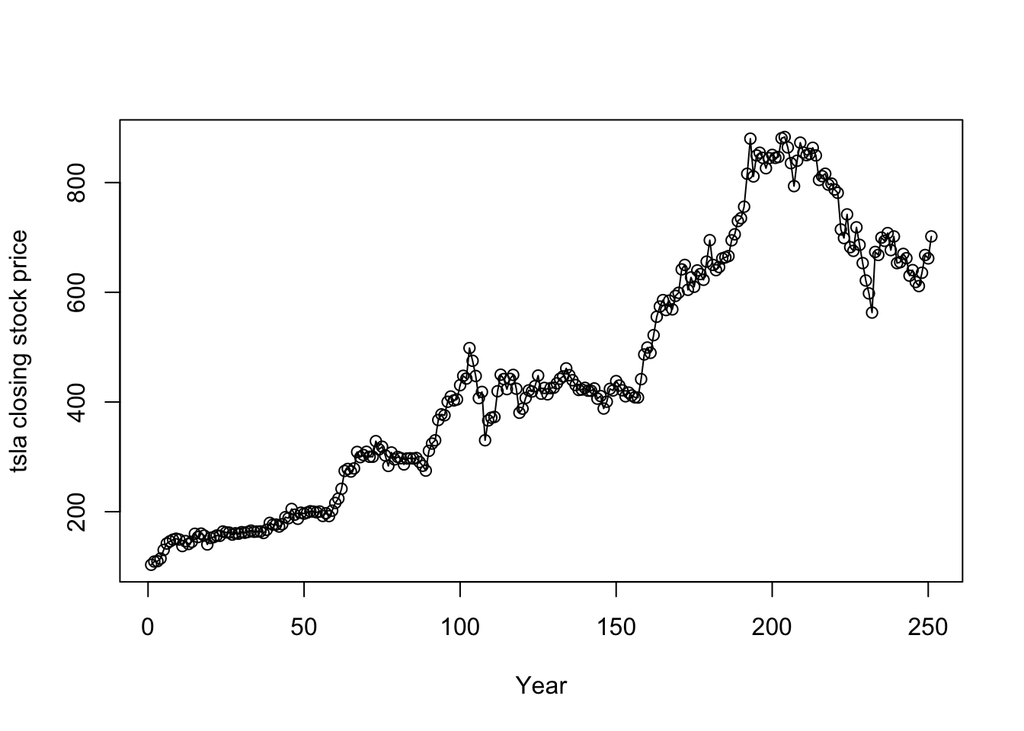

```r
rm(list = ls())
tsla <- ts(read.table("~/Documents/BGSU/time_series_analysis /bonus assignment/tsla.txt", sep=""))
plot(tsla,ylab="tsla closing stock price",xlab="Year",type="o")
```

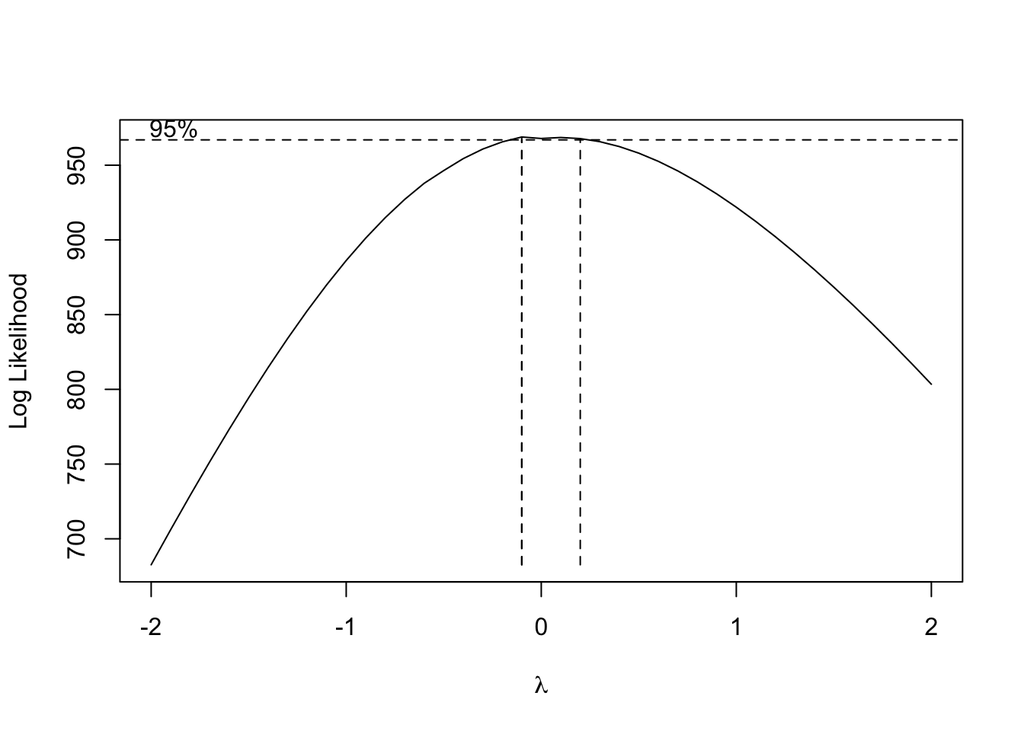

```r
#boxcox transformation
BoxCox.ar(tsla, method= "burg")
```

# From the plot we can see a clear trend hence the data is not stationary

# For the Box-Cox transformation, The (lamda) λ value is 0 so we can do a log transformation.

# log transformation and difference process

[figure not shown]

```r
plot(log(tsla),ylab="Percentage granted review (Log scale)",xlab="Year",type="o")
```

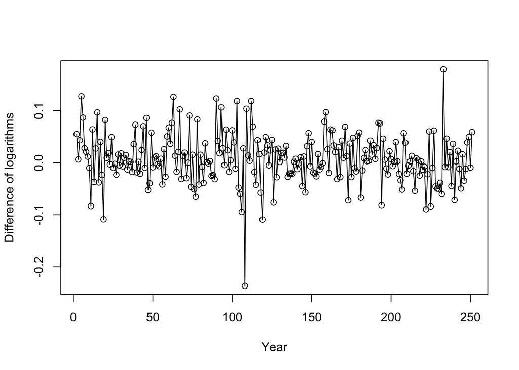

```r
plot(diff(log(tsla)),ylab="Difference of logarithms",xlab="Year",type="o")
```

#The log-transformed series still displays the linear trend, as expected. However, the variance in the {logYt} process is more constant than in the original series. It looks like the log-transformation has “worked”. We are going to take a difference of the log transformed series to make it stationary # The first differences of the log-transformed process appears to be stationary.

```r
# ADF test
adf.test(diff(log(tsla)))
```

```
##
##  Augmented Dickey-Fuller Test
##
## data:  diff(log(tsla))
## Dickey-Fuller = -6.7886, Lag order = 6, p-value = 0.01
## alternative hypothesis: stationary
```